# Lecture Script - Review

Bioengineering Statistics (MA482/BE482)

```r
# This line should be the first line of code executed in your document. It
# ensures that additional functionality is available to you.
source("https://reyesem.github.io/files/MA482/MA482Setup.R")
```

As one of the objectives of this module is to familiarize you with the computing environment, this particular document contains more detail than will be typical moving forward. The additional commentary is meant to help familiarize you with the various aspects of the code.

## Obtain Data

You should store data as a CSV file (this can be done inside any spreadsheet software). Any datasets provided to you on the course Moodle page will also share this format. While you can open such files in any spreadsheet software (e.g., Excel or Google Sheets), we will need to upload them into the computing environment. This is done with the `read_csv()` function. *It is important that the dataset be stored in the same directory (file) as your analysis script.*

```r
# Data is made available on the course Moodle page.
# Download the data to the same file as your analysis script.
cancer <- read_csv("OccupationalHealth.csv")
```

## Summarize Data

As with everything in R, there are many ways to summarize your data. The `skim()` function is nice for summarizing all variables in a dataset. It automatically detects the type of variable in each column and produces an appropriate summary. The results are separated by the type of variable (how R is storing it). While this function does not automatically create production-ready tables, it is a nice way to obtain many summaries quickly. You could then use these in constructing a nicely formatted table in a report. *Homework assignments and analysis tasks need not have nice formatting; case studies, on the other hand, which mimic journal articles should be well formatted.*

```r
# Summarize all variables in the dataset.
skim(cancer)
```

```
Skim summary statistics
 n obs: 13
 n variables: 3

-- Variable type:character -----------------------------------------------------------------------------------
     variable missing complete  n min max empty n_unique
 Cancer Death       0       13 13   2   3     0        2
           top_counts ordered
 No: 8, Yes: 5, NA: 0   FALSE

-- Variable type:numeric -------------------------------------------------------------------------------------
 variable missing complete  n  mean   sd p0 p25 p50 p75 p100
      Age       0       13 13 59.62 3.12 55  57  60  62   64
  Subject       0       13 13  7    3.89  1   4   7  10   13
```

Again, there are many ways to produce graphics. This course will demonstrate the use of the grammar of graphics available in the `ggplot2` package and implemented using the `ggplot()` function. This can seem a bit overwhelming at first, but it allows for extreme flexibility when creating graphics. A nice cheatsheet is available online: https://www.rstudio.org/links/data_visualization_cheat_sheet

The most important thing to keep in mind when using `ggplot()` is that it is built to work with entire datasets. So, the first thing it requires is the dataset that contains the variables which will be used in making the graphic. Next, you need to specify the “mapping,” how the variables in the dataset are linked to various features on the graphic (such as the x- and y-axis or color-axis). This is done through `mapping = aes()` idea. For our plot, we only need to specify the x-axis, which is the variable “Cancer Death” in the dataset. Since this variable name is unusual (has a space), you should surround it with backticks (the symbol in the top-left corner of your keyboard — *not* the same as a single quote).

After specifying the data and mapping, we are ready to create the graphic, which really is about how you want the data to be summarized on the plot. We would like to create a bar chart in which the frequency (number of subjects) within each category are created. So, we “add” this layer to the graphic.

Finally, we can “add” labels to the graphic, one for each axis and an overall title which can function as a caption if needed.

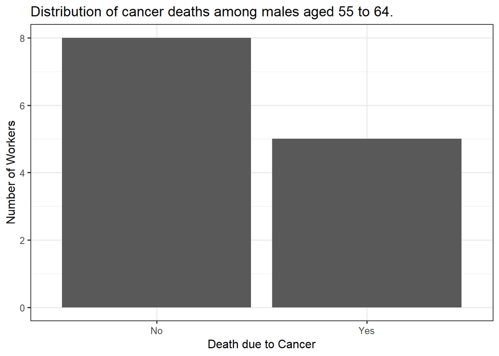

```r
ggplot(data = cancer,
       mapping = aes(x = `Cancer Death`)) +
  geom_bar() +
  labs(y = "Number of Workers",
       x = "Death due to Cancer",
       title = "Distribution of cancer deaths among males aged 55 to 64.")
```

## The Sampling Distribution and Confidence Interval

As we move forward in the course, we will examine various methods for modeling a sampling distribution for a statistic. Regardless of the specific modeling strategy we are utilizing, the concepts are the same. Illustrated below is a process for using a bootstrapping procedure for modeling the sampling distribution of the proportion in the sample.

```r
# Function which computes the proportion of subjects with cancer death.
prop.fct <- function(data, indices){
  mean(data$`Cancer Death`[indices]=="Yes")
}

boot.proportions <- boot(
  data = cancer,
  statistic = prop.fct,
  R = 5000)
```

With each bootstrap replication, a random sample of size `nrow(cancer)` is taken (with replacement) from the original data. This mimics the process of taking another sample of the same size from the population. For each resample, the same statistic (the sample proportion in this case) is computed. These bootstrap statistics are stored for future use. These bootstrap statistics also form the empirical model for the sampling distribution (which is visualized below).

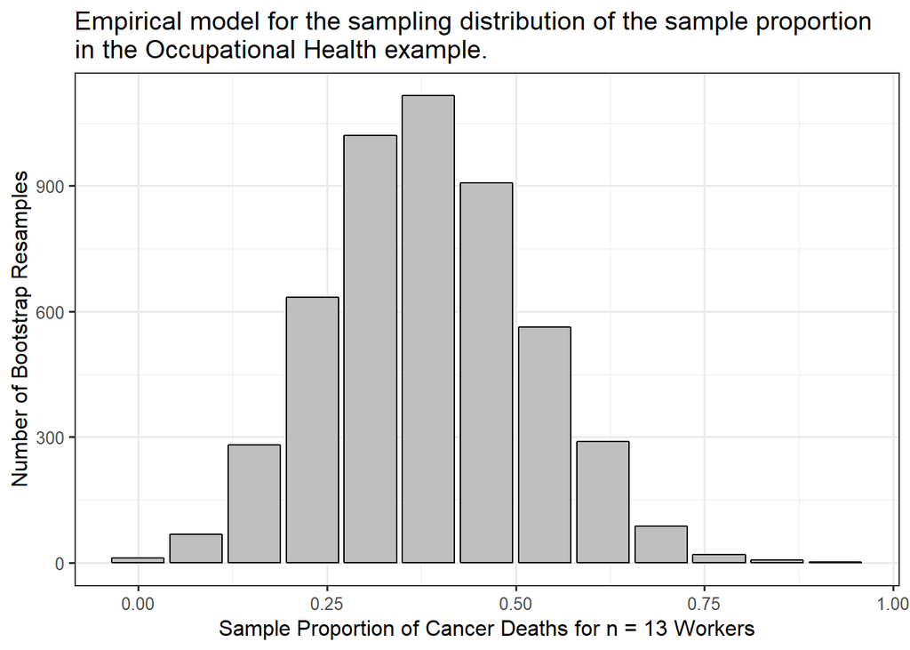

Once we have the model for the sampling distribution, we can form the confidence interval by retaining the middle $100c$% of the model for theh sampling distribution (where $c$ is known as the confidence level).

```r
quantile(boot.proportions$t, probs = c(0.025, 0.975))
```

```
     2.5%     97.5%
0.1538462 0.6153846
```

## The Null Distribution and P-Value

The null distribution tells us what we should expect if the null hypothesis is true. That is, it summarizes what we should expect for a statistic if we resample from a population in which the null hypothesis is true. This is generally done by specifying the model for the data generating process when the null hypothesis is true; that is, we need to know how the response is generated if the null is true. This tells the computer how to do the bootstrapping from that “null world” (the population in which the null hypothesis is true). This is often done behind the scenes as we move forward; however, we do this explicitly here just to emphasize the concepts underlying all modeling strategies.

```r
# Repeated resample from the null world
boot.null.proportions <- replicate(5000, {
  data <- sample(c("No", "Yes"), size = 13, replace = TRUE, prob = c(0.8, 0.2))

  mean(data=="Yes")
})
```

Each bootstrap sample is taken from a world where exactly 20% of the population would have cancer listed as the cause of death. Each sample is the same size as the original sample to maintain sampling variability. Similar to the sampling distribution, the resulting proportions form the entire distribution (which is summarized below).

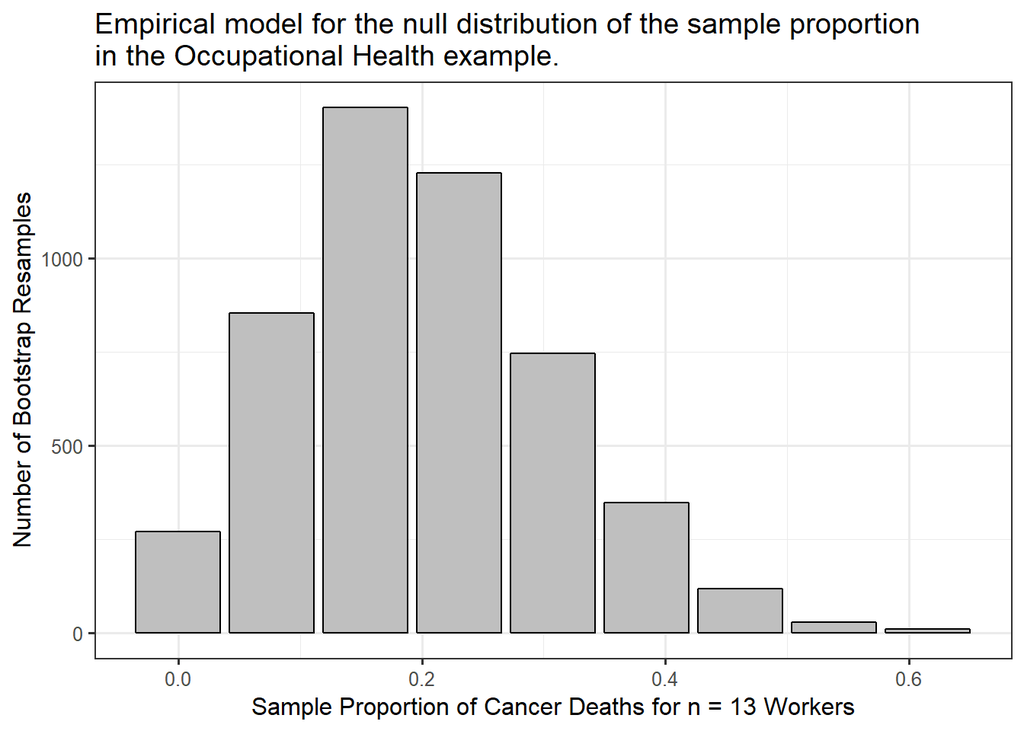

Once we have the model for the null distribution, we can compute the p-value by determining what fraction of the resampled statistics are as extreme or moreso as that we computed in the original sample.

```r
mean(boot.null.proportions >= (5/13)) +
  mean(boot.null.proportions <= (0.2/13))
```

```
[1] 0.1544
```